# **Practical Machine Learning Assignment**

Antoni Parellada

### **Data preparation:**

First let’s load the raw data:

And take a look at it… The dimensions of the training set are `dim(training)` $19622$ rows by $159$ columns. The testing set is $20 \times 159$.

To prepare the data we start by making sure that the variable we want to predict is a factor: `str(training$classe) Factor w/ 5 levels "A","B","C","D"`.

There is a variable `cvtd_timestamp` with dates formatted as `05/12/2011 11:23`. This is bound to cause problems, and it is hard to imagine its having an effect on the model. We can convert from the current structure of `Factor w/ 20 levels "02/12/2011 13:32"` to a POSIX format, but it each entry will be a list, creating other handling issues. For now, we can eliminate this column:

```r
training <- within(training, rm(cvtd_timestamp))
```

Likewise, the first column is just the row numbers, so we remove it:

```r
training <- training[c(-1)]
```

It seems as though there are a lot of columns with an overwhelming majority of `NA` values. Even setting a limit as low as $<5\%$ of non-empty entries, we could eliminate them:

```r
throw_away <- function(x){
empty <- rep(0, length(x))
for(i in 1:length(x)){
    if ((sum(is.na(x[ ,i])) / nrow(x)) > 0.95){ # We throw away columns with less than 5% of observations/no.of rows
        empty[i] <- i
    }
    else{
        empty[i] <- NA
    }
}
    na.omit(empty)
}

training <- training[ ,c(-throw_away(training))]
dim(training)
```

```
## [1] 19622    58
```

Finally we get rid of variables with near-zero variance:

```r
nzv <- nearZeroVar(training, saveMetrics=TRUE)
training <- training[  , nzv$nzv == FALSE]
dim(training)
```

```
## [1] 19622    57
```

### **Training set partitions:**

Now we partition the training dataset into $60\%$ for *sub*-training and $40%$ for *sub*-testing sets to assess out of sample accuracy (cross validation). We can do this by randomly selecting rows:

```r
training_rows <- sample(1:nrow(training), round(0.6 * nrow(training)))
little_train <- training[training_rows, ]

# This corresponds to...
round(100 * nrow(little_train) / nrow(training), 0) # percentage of the training data.
```

```
## [1] 60
```

```r
# And the rest go to the sub-testing set:
little_test  <- training[-training_rows,  ]
dim(little_train); dim(little_test)
```

```
## [1] 11773    57
```

```
## [1] 7849   57
```

### **Data analysis:**

#### **Decision Tree Learning:**

```r
fit <- rpart(classe ~ ., data=little_train, method="class") # Classification tree
printcp(fit)
```

```
##
## Classification tree:
## rpart(formula = classe ~ ., data = little_train, method = "class")
##
## Variables actually used in tree construction:
##  [1] accel_dumbbell_z     accel_forearm_x      magnet_belt_z
##  [4] magnet_dumbbell_y    magnet_dumbbell_z    num_window
##  [7] pitch_belt           pitch_forearm        raw_timestamp_part_1
## [10] roll_belt            roll_dumbbell        total_accel_dumbbell
## [13] yaw_belt
##
## Root node error: 8393/11773 = 0.7129
##
## n= 11773
##
##          CP nsplit rel error  xerror      xstd
## 1  0.116526      0   1.00000 1.00000 0.0058487
## 2  0.047635      1   0.88347 0.88407 0.0062407
## 3  0.041225      7   0.58477 0.69463 0.0064636
## 4  0.035506      8   0.54355 0.58310 0.0063714
## 5  0.032170      9   0.50804 0.55105 0.0063137
## 6  0.030144     10   0.47587 0.52008 0.0062443
## 7  0.029310     11   0.44573 0.49982 0.0061913
## 8  0.025180     12   0.41642 0.46193 0.0060756
## 9  0.016681     16   0.31526 0.35565 0.0056241
## 10 0.014476     17   0.29858 0.28822 0.0052234
## 11 0.013344     19   0.26963 0.26951 0.0050933
## 12 0.010604     20   0.25628 0.25200 0.0049629
## 13 0.010247     23   0.22447 0.23281 0.0048099
## 14 0.010000     24   0.21423 0.23043 0.0047901
```

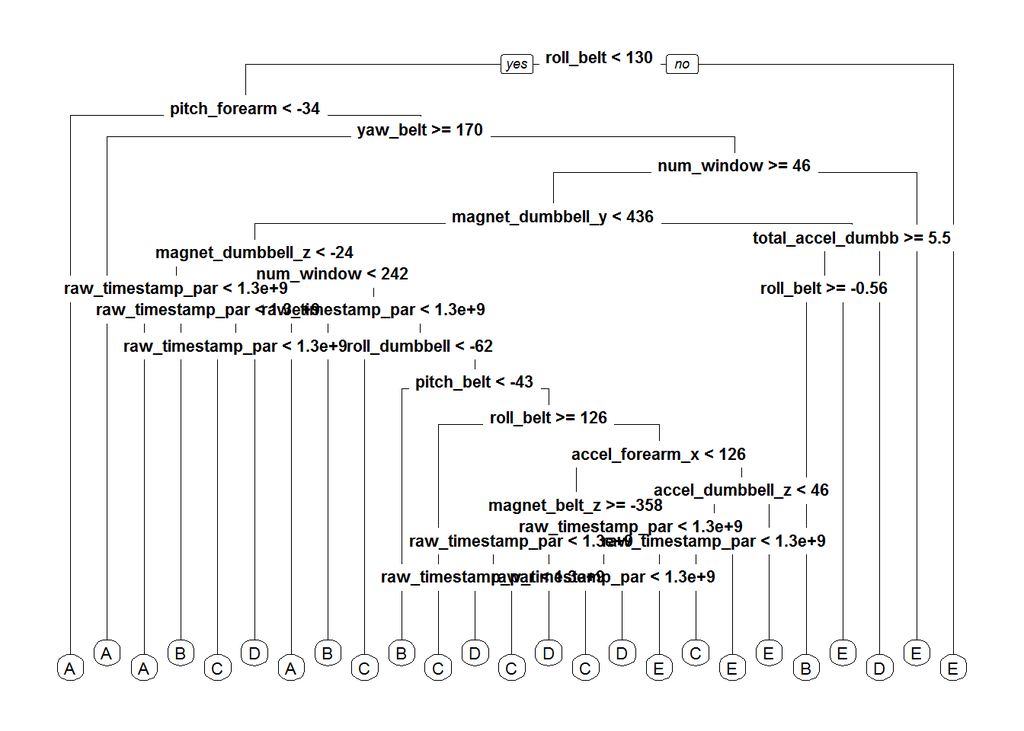

```r
bestcp <- fit$cptable[which.min(fit$cptable[,"xerror"]),"CP"]
fit.pruned <- prune(fit, cp = bestcp)
prp(fit.pruned, cex=0.7, fallen.leaves = T,under = T)
```

```r
fit
```

```
## n= 11773
##
## node), split, n, loss, yval, (yprob)
##       * denotes terminal node
##
##     1) root 11773 8393 A (0.29 0.19 0.17 0.16 0.18)
##       2) roll_belt< 130.5 10771 7403 A (0.31 0.21 0.19 0.18 0.11)
##         4) pitch_forearm< -34.35 934    3 A (1 0.0032 0 0 0) *
##         5) pitch_forearm>=-34.35 9837 7400 A (0.25 0.23 0.21 0.19 0.12)
##          10) yaw_belt>=169.5 499   48 A (0.9 0.042 0 0.05 0.004) *
##          11) yaw_belt< 169.5 9338 7080 B (0.21 0.24 0.22 0.2 0.13)
##            22) num_window>=45.5 8901 6643 B (0.22 0.25 0.23 0.2 0.094)
##              44) magnet_dumbbell_y< 436.5 7489 5517 C (0.26 0.2 0.26 0.19 0.09)
##                88) magnet_dumbbell_z< -24.5 2431 1255 A (0.48 0.23 0.12 0.13 0.029)
##                 176) raw_timestamp_part_1< 1.323095e+09 1547  371 A (0.76 0.17 0.02 0.034 0.012) *
##                 177) raw_timestamp_part_1>=1.323095e+09 884  586 B (0 0.34 0.3 0.31 0.06)
##                   354) raw_timestamp_part_1< 1.323095e+09 304    6 B (0 0.98 0.02 0 0) *
##                   355) raw_timestamp_part_1>=1.323095e+09 580  310 D (0 0 0.44 0.47 0.091)
##                     710) raw_timestamp_part_1< 1.323095e+09 253    0 C (0 0 1 0 0) *
##                     711) raw_timestamp_part_1>=1.323095e+09 327   57 D (0 0 0.012 0.83 0.16) *
##                89) magnet_dumbbell_z>=-24.5 5058 3380 C (0.15 0.18 0.33 0.22 0.12)
##                 178) num_window< 241.5 579   47 A (0.92 0.0017 0.041 0.0052 0.033) *
##                 179) num_window>=241.5 4479 2825 C (0.049 0.2 0.37 0.25 0.13)
##                   358) raw_timestamp_part_1< 1.32249e+09 411   64 B (0.15 0.84 0.0024 0 0) *
##                   359) raw_timestamp_part_1>=1.32249e+09 4068 2415 C (0.038 0.14 0.41 0.28 0.14)
##                     718) roll_dumbbell< -61.80313 746   88 C (0 0.043 0.88 0.067 0.008) *
##                     719) roll_dumbbell>=-61.80313 3322 2250 D (0.047 0.16 0.3 0.32 0.17)
##                      1438) pitch_belt< -42.85 310   54 B (0.013 0.83 0.13 0.026 0.0097) *
##                      1439) pitch_belt>=-42.85 3012 1948 D (0.05 0.089 0.32 0.35 0.19)
##                        2878) roll_belt>=125.5 339   23 C (0 0.044 0.93 0.021 0.0029) *
##                        2879) roll_belt< 125.5 2673 1616 D (0.056 0.095 0.24 0.4 0.21)
##                          5758) accel_forearm_x< 125.5 2008  995 D (0.055 0.092 0.19 0.5 0.16)
##                           11516) magnet_belt_z>=-358.5 1485  659 D (0.075 0.12 0.2 0.56 0.044)
##                             23032) raw_timestamp_part_1< 1.322673e+09 401  223 C (0.13 0.17 0.44 0.25 0.0025)
##                               46064) raw_timestamp_part_1< 1.322673e+09 223  122 D (0.24 0.3 0 0.45 0.0045) *
##                               46065) raw_timestamp_part_1>=1.322673e+09 178    0 C (0 0 1 0 0) *
##                             23033) raw_timestamp_part_1>=1.322673e+09 1084  359 D (0.053 0.11 0.11 0.67 0.059) *
##                           11517) magnet_belt_z< -358.5 523  276 E (0 0 0.17 0.36 0.47)
##                             23034) raw_timestamp_part_1< 1.32249e+09 270   87 D (0 0 0.32 0.68 0)
##                               46068) raw_timestamp_part_1< 1.32249e+09 86    0 C (0 0 1 0 0) *
##                               46069) raw_timestamp_part_1>=1.32249e+09 184    1 D (0 0 0.0054 0.99 0) *
##                             23035) raw_timestamp_part_1>=1.32249e+09 253    6 E (0 0 0.0079 0.016 0.98) *
##                          5759) accel_forearm_x>=125.5 665  406 E (0.06 0.11 0.38 0.066 0.39)
##                           11518) accel_dumbbell_z< 45.5 511  259 C (0.078 0.14 0.49 0.072 0.22)
##                             23036) raw_timestamp_part_1< 1.322673e+09 389  137 C (0.098 0.16 0.65 0.093 0) *
##                             23037) raw_timestamp_part_1>=1.322673e+09 122   10 E (0.016 0.057 0 0.0082 0.92) *
##                           11519) accel_dumbbell_z>=45.5 154    7 E (0 0 0 0.045 0.95) *
##              45) magnet_dumbbell_y>=436.5 1412  627 B (0.042 0.56 0.045 0.24 0.12)
##                90) total_accel_dumbbell>=5.5 980  265 B (0.061 0.73 0.063 0.026 0.12)
##                 180) roll_belt>=-0.56 891  176 B (0.067 0.8 0.07 0.028 0.033) *
##                 181) roll_belt< -0.56 89    0 E (0 0 0 0 1) *
##                91) total_accel_dumbbell< 5.5 432  116 D (0 0.16 0.0023 0.73 0.1) *
##            23) num_window< 45.5 437   91 E (0 0 0 0.21 0.79) *
##       3) roll_belt>=130.5 1002   12 E (0.012 0 0 0 0.99) *
```

```r
p = predict(fit, little_test, type = "class")
```

The confusion matrix is:

```r
table(actual = little_test$classe, predicted = p)
```

```
##       predicted
## actual    A    B    C    D    E
##      A 2027   77   20   74    2
##      B  189 1091   70  159    6
##      C   31   72 1204   73    7
##      D   60   29   69 1085   69
##      E   22   27    8  104 1274
```

```r
# Or with the built-in R function from caret:
confusionMatrix(p, little_test$classe)
```

```
## Confusion Matrix and Statistics
##
##           Reference
## Prediction    A    B    C    D    E
##          A 2027  189   31   60   22
##          B   77 1091   72   29   27
##          C   20   70 1204   69    8
##          D   74  159   73 1085  104
##          E    2    6    7   69 1274
##
## Overall Statistics
##
##                Accuracy : 0.8512
##                  95% CI : (0.8431, 0.859)
##     No Information Rate : 0.2803
##     P-Value [Acc > NIR] : < 2.2e-16
##
##                   Kappa : 0.8118
##  Mcnemar's Test P-Value : < 2.2e-16
##
## Statistics by Class:
##
##                      Class: A Class: B Class: C Class: D Class: E
## Sensitivity            0.9214   0.7201   0.8681   0.8270   0.8878
## Specificity            0.9465   0.9676   0.9742   0.9373   0.9869
## Pos Pred Value         0.8703   0.8418   0.8782   0.7258   0.9381
## Neg Pred Value         0.9687   0.9353   0.9718   0.9643   0.9752
## Prevalence             0.2803   0.1930   0.1767   0.1672   0.1828
## Detection Rate         0.2582   0.1390   0.1534   0.1382   0.1623
## Detection Prevalence   0.2967   0.1651   0.1747   0.1905   0.1730
## Balanced Accuracy      0.9340   0.8439   0.9211   0.8821   0.9374
```

#### **Random Forest:**

```r
fit2 <- randomForest(classe ~ ., data=little_train)
p2 = predict(fit2, little_test, type = "class")
confusionMatrix(p2, little_test$classe)
```

```
## Confusion Matrix and Statistics
##
##           Reference
## Prediction    A    B    C    D    E
##          A 2200    2    0    0    0
##          B    0 1513    9    0    0
##          C    0    0 1378    8    0
##          D    0    0    0 1304    6
##          E    0    0    0    0 1429
##
## Overall Statistics
##
##                Accuracy : 0.9968
##                  95% CI : (0.9953, 0.9979)
##     No Information Rate : 0.2803
##     P-Value [Acc > NIR] : < 2.2e-16
##
##                   Kappa : 0.996
##  Mcnemar's Test P-Value : NA
##
## Statistics by Class:
##
##                      Class: A Class: B Class: C Class: D Class: E
## Sensitivity            1.0000   0.9987   0.9935   0.9939   0.9958
## Specificity            0.9996   0.9986   0.9988   0.9991   1.0000
## Pos Pred Value         0.9991   0.9941   0.9942   0.9954   1.0000
## Neg Pred Value         1.0000   0.9997   0.9986   0.9988   0.9991
## Prevalence             0.2803   0.1930   0.1767   0.1672   0.1828
## Detection Rate         0.2803   0.1928   0.1756   0.1661   0.1821
## Detection Prevalence   0.2805   0.1939   0.1766   0.1669   0.1821
## Balanced Accuracy      0.9998   0.9986   0.9961   0.9965   0.9979
```

### **Test Data Prediction:**

```r
predict(fit2, testing, type = "class")
```

```
##  1  2  3  4  5  6  7  8  9 10 11 12 13 14 15 16 17 18 19 20
##  B  A  B  A  A  E  D  B  A  A  B  C  B  A  E  E  A  B  B  B
## Levels: A B C D E
```